# Customer Segmentation with K-Means Clustering

K-means clustering can be used to classify observations into k groups, based on their similarity. Each group is represented by the mean value of points in the group, known as the cluster centroid.

K-means algorithm requires users to specify the number of cluster to generate. The R function kmeans() [stats package] can be used to compute k-means algorithm. The simplified format is kmeans(x, centers), where “x” is the data and centers is the number of clusters to be produced.

After, computing k-means clustering, the R function fviz_cluster() [factoextra package] can be used to visualize the results. The format is fviz_cluster(km.res, data), where km.res is k-means results and data corresponds to the original data sets.

Loading the data set

```r
# Loading the data set
customer_data=read.csv("C:/Users/soura/Downloads/Mall_Customers.csv", header = TRUE)
```

data link- https://www.kaggle.com/datasets/vjchoudhary7/customer-segmentation-tutorial-in-python/download?datasetVersionNumber=1

Viewing the first 3 rows of the data

```r
head(customer_data,n=3)
```

|  | CustomerID | Gender | Age | Annual.Income..k.. | Spending.Score..1.100. |
| --- | --- | --- | --- | --- | --- |
| 1 | 1 | Male | 19 | 15 | 39 |
| 2 | 2 | Male | 21 | 15 | 81 |
| 3 | 3 | Female | 20 | 16 | 6 |

finding the number of rows and columns

```r
nrow(customer_data)  # number of rows
```

```
## [1] 200
```

```r
ncol(customer_data)  # number of columns
```

```
## [1] 5
```

First value 200 represents number of rows so we have the data for 200 different customers and the second value 5 represents number of columns.

Getting some information about the data set

```r
str(customer_data)
```

```
## 'data.frame':    200 obs. of  5 variables:
##  $ CustomerID            : int  1 2 3 4 5 6 7 8 9 10 ...
##  $ Gender                : chr  "Male" "Male" "Female" "Female" ...
##  $ Age                   : int  19 21 20 23 31 22 35 23 64 30 ...
##  $ Annual.Income..k..    : int  15 15 16 16 17 17 18 18 19 19 ...
##  $ Spending.Score..1.100.: int  39 81 6 77 40 76 6 94 3 72 ...
```

```r
summary(customer_data)
```

```
##    CustomerID        Gender               Age        Annual.Income..k..
##  Min.   :  1.00   Length:200         Min.   :18.00   Min.   : 15.00
##  1st Qu.: 50.75   Class :character   1st Qu.:28.75   1st Qu.: 41.50
##  Median :100.50   Mode  :character   Median :36.00   Median : 61.50
##  Mean   :100.50                      Mean   :38.85   Mean   : 60.56
##  3rd Qu.:150.25                      3rd Qu.:49.00   3rd Qu.: 78.00
##  Max.   :200.00                      Max.   :70.00   Max.   :137.00
##  Spending.Score..1.100.
##  Min.   : 1.00
##  1st Qu.:34.75
##  Median :50.00
##  Mean   :50.20
##  3rd Qu.:73.00
##  Max.   :99.00
```

From structure we can conclude that data consists of 4 numerical data (CustomerID , Age , Annual Income, Spending.Score) and 1 categorical data(Gender).

From above summary we can conclude that minimum age is 18 and maximum age is 70. Minimum annual income is 15 and maximum annual income is 137. Minimum spending score is 1 and maximum spending score is 99.

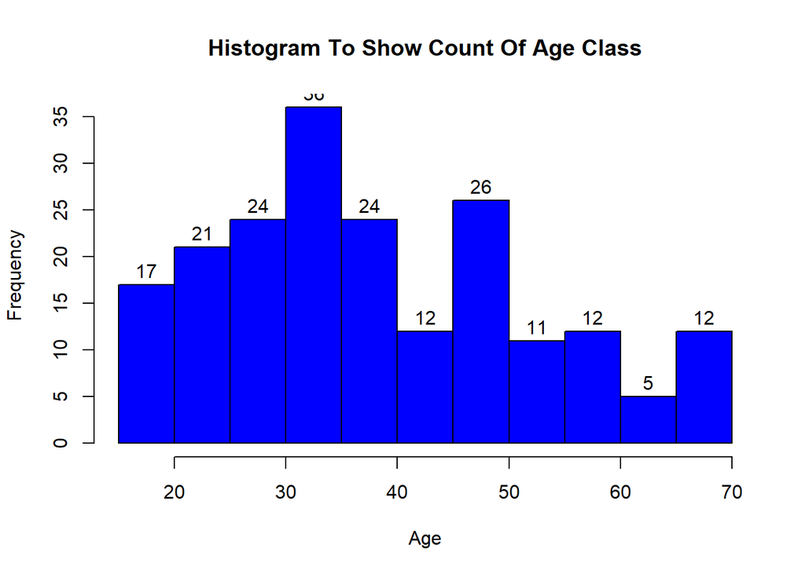

```r
# Age
hist(customer_data$Age,
     main = "Histogram To Show Count Of Age Class",
     xlab = "Age",
     ylab = "Frequency",
     col = "blue",
     labels = TRUE)
```

From Histogram plot of age we can see the distribution plot of the frequency customer age and conclude that age is well distrubuted.

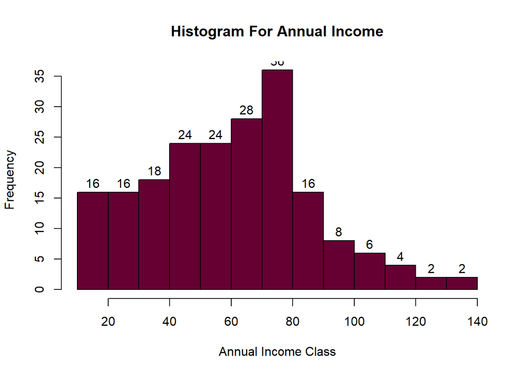

```r
# Annual Income
hist(customer_data$Annual.Income..k..,
     main = "Histogram For Annual Income",
     xlab = "Annual Income Class",
     ylab = "Frequency",
     col = "#660033",
     labels = TRUE)
```

From Histogram plot of annual income we can see the distribution plot of the frequency of customer’s annual income and conclude that annual income is well distributed.

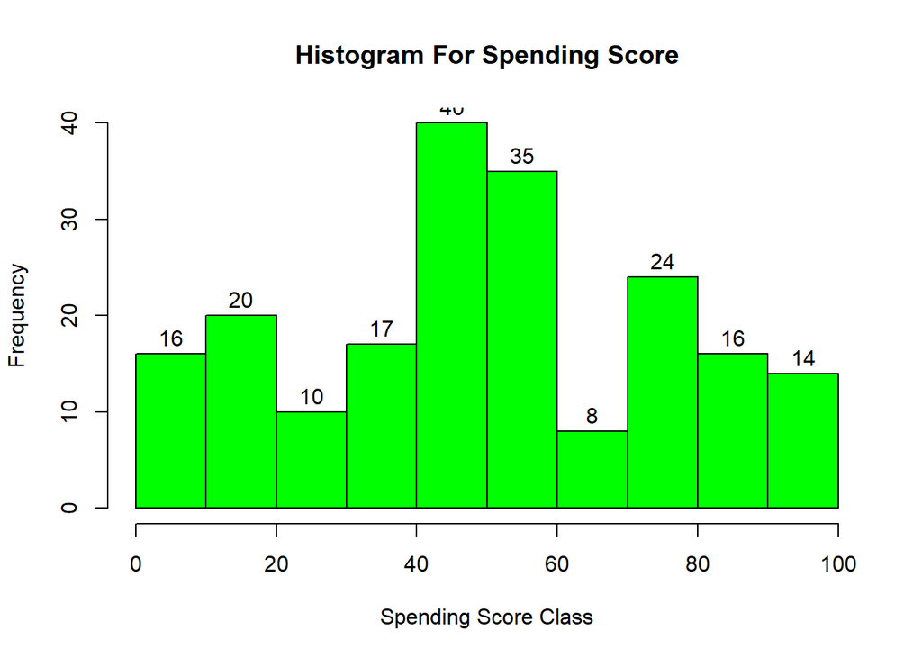

```r
# Spending Score
hist(customer_data$Spending.Score..1.100.,
     main = "Histogram For Spending Score",
     xlab = "Spending Score Class",
     ylab = "Frequency",
     col = "green",
     labels = TRUE)
```

From Histogram plot of Spending Score we can see the distribution plot of the frequency of customer’s Spending Score and conclude that Spending Score is well distrubuted.

checking for missing values

```r
# checking for missing values
colSums(is.na(customer_data))
```

```
##             CustomerID                 Gender                    Age
##                      0                      0                      0
##     Annual.Income..k.. Spending.Score..1.100.
##                      0                      0
```

We don’t have any missing values in this data set.

```r
data<-customer_data[,c(4,5)]
```

The first column CustomerID is not required because it is not an actual attribute.The second column is not also required because it is a categorical data,we can’t measure distance in categorical data. We are also not choosing age because age is also that much required. So we are creating a data frame including numerical data which are Annual income and Spending score for K-Means Clustering.

scaling data

```r
df<-scale(data)
```

Finding the optimal number of clusters using elbow method

```r
# Load necessary libraries
library(factoextra)
```

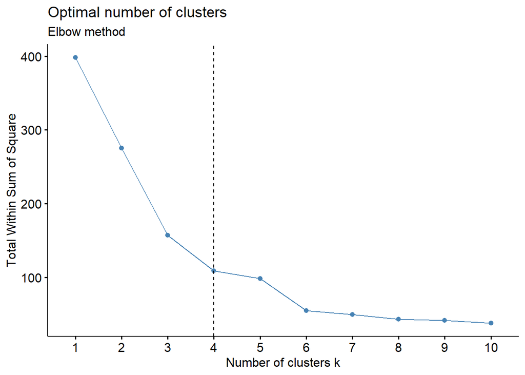

```r
fviz_nbclust(df, kmeans, method = "wss") +
  geom_vline(xintercept = 4, linetype = 2) +
  labs(subtitle = "Elbow method")
```

Optimum number of cluster = 4

The standard R function for k-means clustering is kmeans() [stats package], which simplified format is as follow:

kmeans(x, centers, iter.max = 10, nstart = 1) x: numeric matrix, numeric data frame or a numeric vector centers: Possible values are the number of clusters (k) or a set of initial (distinct) cluster centers. If a number, a random set of (distinct) rows in x is chosen as the initial centers. iter.max: The maximum number of iterations allowed. Default value is 10. nstart: The number of random starting partitions when centers is a number. Trying nstart > 1 is often recommended.

Compute kmeans with k=4

```r
km.res <- kmeans(df, 4, nstart = 25)
```

As the final result of k-means clustering result is sensitive to the random starting assignments, we specify nstart = 25. This means that R will try 25 different random starting assignments and then select the best results corresponding to the one with the lowest within cluster variation. The default value of nstart in R is one. But, it’s strongly recommended to compute k-means clustering with a large value of nstart such as 25 or 50, in order to have a more stable result.

Print the result

```r
print(km.res)
```

```
## K-means clustering with 4 clusters of sizes 39, 23, 100, 38
##
## Cluster means:
##   Annual.Income..k.. Spending.Score..1.100.
## 1          0.9891010              1.2364001
## 2         -1.3042458             -1.1341194
## 3         -0.4683088              0.2431891
## 4          1.0066735             -1.2224677
##
## Clustering vector:
##   [1] 2 3 2 3 2 3 2 3 2 3 2 3 2 3 2 3 2 3 2 3 2 3 2 3 2 3 2 3 2 3 2 3 2 3 2 3 2
##  [38] 3 2 3 2 3 2 3 2 3 3 3 3 3 3 3 3 3 3 3 3 3 3 3 3 3 3 3 3 3 3 3 3 3 3 3 3 3
##  [75] 3 3 3 3 3 3 3 3 3 3 3 3 3 3 3 3 3 3 3 3 3 3 3 3 3 3 3 3 3 3 3 3 3 3 3 3 3
## [112] 3 3 3 3 3 3 3 3 3 3 3 3 1 4 1 4 1 4 1 4 1 4 1 4 1 4 1 4 1 4 1 4 1 4 1 4 1
## [149] 4 1 4 1 4 1 4 1 4 1 4 1 4 1 4 1 4 1 4 1 4 1 4 1 4 1 4 1 4 1 4 1 4 1 4 1 4
## [186] 1 4 1 4 1 4 1 4 1 4 1 4 1 4 1
##
## Within cluster sum of squares by cluster:
## [1] 19.655252  7.577407 60.332163 20.811888
##  (between_SS / total_SS =  72.8 %)
##
## Available components:
##
## [1] "cluster"      "centers"      "totss"        "withinss"     "tot.withinss"
## [6] "betweenss"    "size"         "iter"         "ifault"
```

The printed output displays:

the cluster means or centers: a matrix, which rows are cluster number (1 to 4) and columns are variables the clustering vector: A vector of integers (from 1:k) indicating the cluster to which each point is allocated.

Adding the point classification to the original data

```r
dd <- cbind(customer_data, cluster = km.res$cluster)
head(dd)
```

|  | CustomerID | Gender | Age | Annual.Income..k.. | Spending.Score..1.100. | cluster |
| --- | --- | --- | --- | --- | --- | --- |
| 1 | 1 | Male | 19 | 15 | 39 | 2 |
| 2 | 2 | Male | 21 | 15 | 81 | 3 |
| 3 | 3 | Female | 20 | 16 | 6 | 2 |
| 4 | 4 | Female | 23 | 16 | 77 | 3 |
| 5 | 5 | Female | 31 | 17 | 40 | 2 |
| 6 | 6 | Female | 22 | 17 | 76 | 3 |

visualizing the clusters

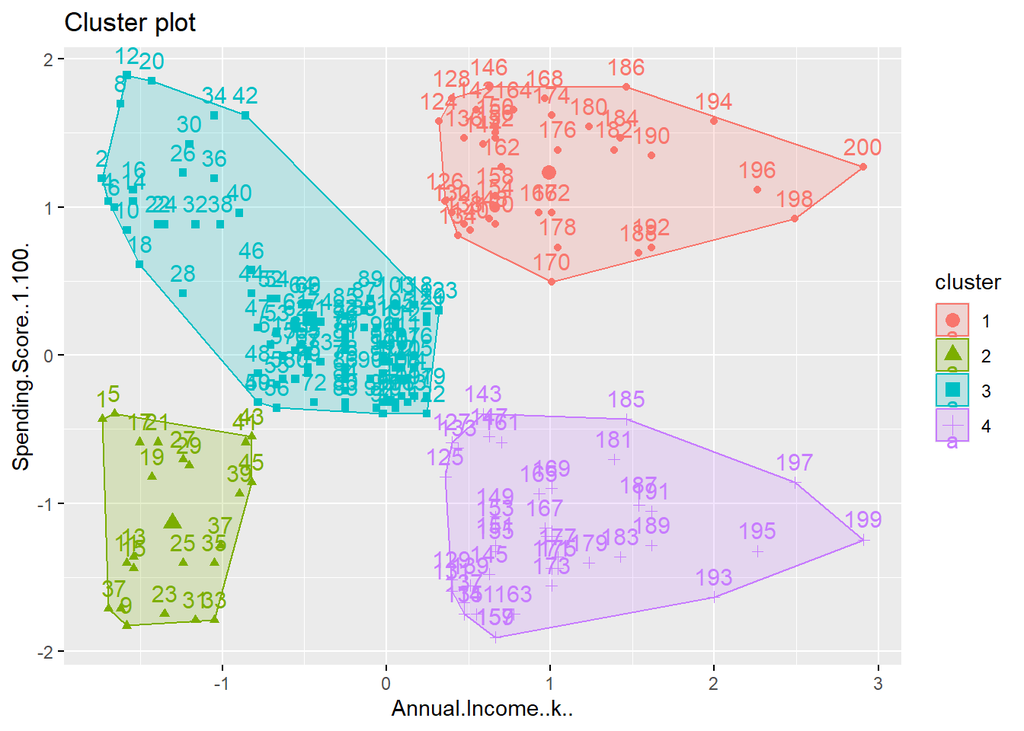

```r
fviz_cluster(km.res, data = df)
```

So from these project we went through Customer Segmentation model,we developed this using class of machine learning known as unsupervised learning and specially we made use of clustering algorithm called k-means clustering.we analyze and visualize the data then proceeded to implement our algorithm.